# Waste Collection in the Port of Genoa (2008-2018)

The classification of waste at European level is based on the European List of Waste (Commission Decision 2000/532/EC – consolidated version) and Annex III to Directive 2008/98/EC (consolidated version). The List of Waste (LoW) provides an EU-wide common terminology for waste classification to ease waste management, including for hazardous waste. The assignment of LoW codes serves in a broad variety of activities, including the transport of waste, installation permits (which often refer also to specific waste codes), or as a basis for waste statistics. According to Decision 2000/532/EC, the LoW should be revised regularly on the basis of new knowledge and, in particular, of research results. The last amendment is Commission Decision 2014/955/EU, which followed a specific study on the review of the European LoW. (see https://ec.europa.eu/environment/waste/framework/list.htm for details).

Numbers related to the waste collection in the Port of Genoa 2008-2018 in tonnes according to EU Directive 2008/98/EC “at a glance”, follows. Please note that EWC (European Waste Code) is translated with CER (Codice Europeo Rifiuto) in Italian language.

The dataset organized by CER codes is publicly provided by the Ports of Genoa  
(https://www.portsofgenoa.com/it/comunicazione-marketing/news/2560-nuovo-piano-gestione-rifiuti.html)

### Data summary (tonnes per year - all CER (LoW) codes)

| 2008 | 2009 | 2010 | 2011 | 2012 | 2013 | 2014 | 2015 | 2016 | 2017 | 2018 |
| --- | --- | --- | --- | --- | --- | --- | --- | --- | --- | --- |
| 7877.45 | 8254.98 | 10045.51 | 8205.4 | 2902.87 | 3836.52 | 6317.8 | 11803.54 | 18638.33 | 18436.98 | 21712.13 |

### Chart

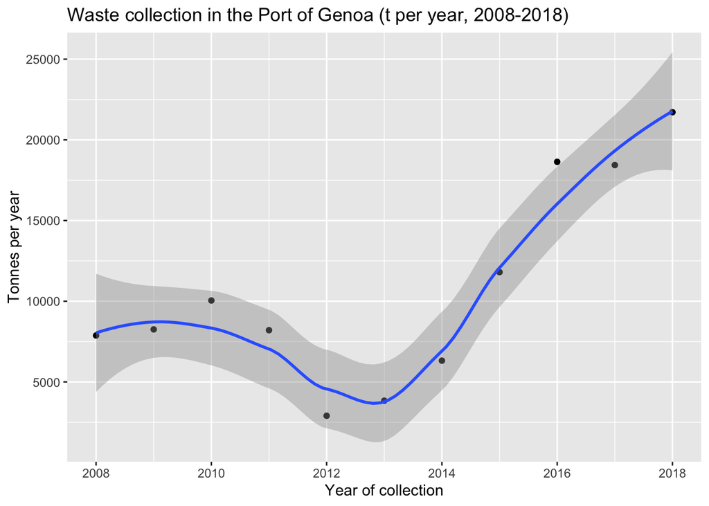

### Focus on Dangerous Waste collection

The overall numbers of collection of dangerous waste in the Port of Genoa 2008-2018 in tonnes according to EU Directive 2008/98/CE follows.

### Data summary (tonnes per year - Dangerous Waste CER (LoW) codes)

| 2008 | 2009 | 2010 | 2011 | 2012 | 2013 | 2014 | 2015 | 2016 | 2017 | 2018 |
| --- | --- | --- | --- | --- | --- | --- | --- | --- | --- | --- |
| 1131.82 | 1132.41 | 1730.32 | 1338.41 | 476.27 | 293.51 | 640.73 | 2146.59 | 4670.41 | 1159.38 | 1554.31 |

### Chart

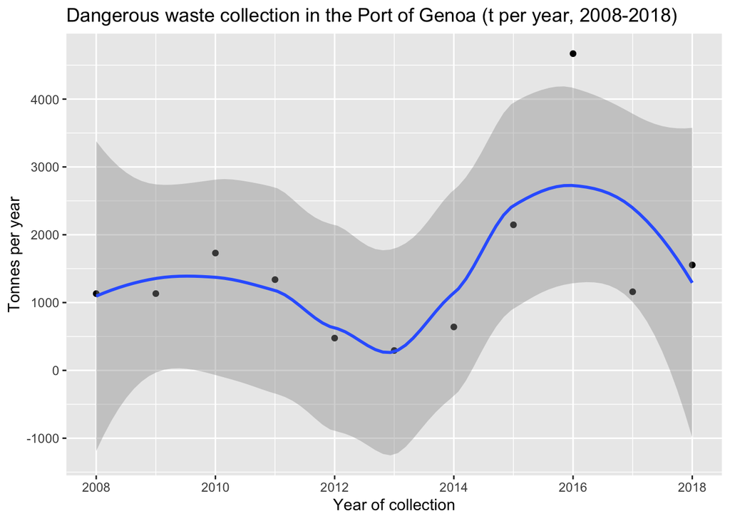

The following tables summarize the detail of collection of dangerous waste in the Port of Genoa 2008-2018 in tonnes according to EU Directive 2008/98/CE.

|  | CER_050103 | CER_060106 | CER_070104 | CER_070208 | CER_070601 | CER_070704 | CER_080111 | CER_080117 | CER_080121 | CER_080409 | CER_090101 | CER_090105 | CER_120114 | CER_120116 | CER_120301 |
| --- | --- | --- | --- | --- | --- | --- | --- | --- | --- | --- | --- | --- | --- | --- | --- |
| 2008 | 95.37 | 0.18 | 0.0 | 0.00 | 0.00 | 0.00 | 11.17 | 0.00 | 0.00 | 0.00 | 4.46 | 0.00 | 481.90 | 0.00 | 0.00 |
| 2009 | 41.15 | 6.10 | 0.0 | 0.00 | 0.38 | 0.38 | 22.85 | 0.00 | 0.00 | 0.00 | 25.84 | 0.00 | 476.17 | 0.00 | 0.00 |
| 2010 | 68.61 | 0.00 | 0.0 | 0.00 | 0.00 | 0.00 | 21.60 | 0.00 | 0.00 | 0.00 | 55.76 | 0.00 | 884.92 | 0.00 | 0.00 |
| 2011 | 38.01 | 0.00 | 0.0 | 0.00 | 0.00 | 0.00 | 23.05 | 0.00 | 0.00 | 0.00 | 61.42 | 0.00 | 553.43 | 0.00 | 0.00 |
| 2012 | 21.91 | 0.00 | 0.0 | 0.00 | 0.00 | 1.97 | 5.37 | 13.68 | 0.00 | 0.10 | 68.65 | 0.62 | 205.55 | 0.00 | 0.00 |
| 2013 | 14.20 | 0.00 | 0.0 | 0.00 | 0.00 | 0.00 | 3.21 | 0.00 | 0.00 | 0.00 | 72.86 | 0.00 | 50.03 | 0.00 | 0.00 |
| 2014 | 46.83 | 1.03 | 0.0 | 0.00 | 0.00 | 0.00 | 4.93 | 0.00 | 0.00 | 0.00 | 57.88 | 0.00 | 151.79 | 0.00 | 0.00 |
| 2015 | 41.40 | 0.00 | 0.0 | 11.80 | 0.00 | 0.00 | 26.39 | 0.00 | 0.30 | 1.94 | 139.98 | 0.00 | 620.77 | 2.24 | 0.00 |
| 2016 | 19.66 | 0.00 | 0.4 | 11.44 | 0.00 | 0.00 | 33.38 | 0.00 | 4.05 | 0.00 | 86.20 | 0.00 | 369.00 | 0.00 | 17.52 |
| 2017 | 23.34 | 0.00 | 0.0 | 0.00 | 0.00 | 0.00 | 39.80 | 0.00 | 13.03 | 0.00 | 72.05 | 0.00 | 446.07 | 0.02 | 0.00 |
| 2018 | 33.89 | 0.00 | 0.0 | 0.00 | 0.00 | 0.00 | 24.43 | 0.00 | 11.54 | 6.24 | 83.88 | 0.00 | 644.64 | 0.05 | 0.00 |
| Total | 444.37 | 7.31 | 0.4 | 23.24 | 0.38 | 2.35 | 216.18 | 13.68 | 28.92 | 8.28 | 728.98 | 0.62 | 4884.27 | 2.31 | 17.52 |

|  | CER_130205 | CER_130206 | CER_130502 | CER_130507 | CER_130802 | CER_140603 | CER_150110 | CER_150202 | CER_160104 | CER_160107 | CER_160121 | CER_160211 | CER_160213 | CER_160215 | CER_160303 |
| --- | --- | --- | --- | --- | --- | --- | --- | --- | --- | --- | --- | --- | --- | --- | --- |
| 2008 | 1.22 | 0.00 | 0.00 | 0.00 | 0.0 | 1.67 | 133.48 | 224.78 | 0.00 | 0.95 | 0.00 | 0.00 | 6.02 | 0.00 | 0.00 |
| 2009 | 1.28 | 0.00 | 0.00 | 0.00 | 0.0 | 3.84 | 168.87 | 231.77 | 0.00 | 0.71 | 0.28 | 0.00 | 31.27 | 0.00 | 0.00 |
| 2010 | 0.82 | 0.00 | 0.00 | 0.00 | 0.0 | 4.27 | 191.67 | 265.87 | 0.00 | 0.70 | 0.00 | 0.00 | 20.98 | 0.00 | 0.00 |
| 2011 | 1.17 | 0.00 | 0.00 | 0.00 | 0.0 | 1.06 | 100.32 | 170.70 | 0.00 | 2.53 | 0.00 | 0.00 | 26.99 | 0.00 | 0.00 |
| 2012 | 0.00 | 0.00 | 0.00 | 0.00 | 0.0 | 0.26 | 33.67 | 101.29 | 0.00 | 1.70 | 0.00 | 0.00 | 0.80 | 0.06 | 0.00 |
| 2013 | 0.03 | 0.00 | 0.00 | 0.00 | 0.0 | 0.18 | 29.64 | 73.54 | 0.00 | 0.82 | 0.00 | 0.07 | 1.14 | 0.00 | 0.00 |
| 2014 | 0.00 | 0.00 | 0.00 | 0.00 | 0.0 | 0.26 | 76.21 | 213.13 | 0.00 | 3.58 | 0.00 | 0.00 | 11.74 | 0.00 | 0.00 |
| 2015 | 0.38 | 0.00 | 0.00 | 0.00 | 0.0 | 0.56 | 236.43 | 649.25 | 0.00 | 6.80 | 115.19 | 1.09 | 7.45 | 0.00 | 0.00 |
| 2016 | 0.46 | 2.34 | 1.38 | 57.88 | 140.9 | 1.03 | 141.62 | 321.54 | 0.00 | 1.52 | 37.55 | 0.67 | 6.02 | 0.00 | 0.26 |
| 2017 | 2.20 | 0.00 | 0.20 | 0.00 | 0.0 | 6.74 | 125.79 | 284.70 | 2.42 | 1.94 | 6.23 | 2.33 | 9.65 | 0.00 | 1.70 |
| 2018 | 5.61 | 0.00 | 0.00 | 0.00 | 0.0 | 8.42 | 139.38 | 340.83 | 34.58 | 2.06 | 1.96 | 8.49 | 7.90 | 0.00 | 20.86 |
| Total | 13.17 | 2.34 | 1.58 | 57.88 | 140.9 | 28.29 | 1377.08 | 2877.40 | 37.00 | 23.31 | 161.21 | 12.65 | 129.96 | 0.06 | 22.82 |

|  | CER_160403 | CER_160504 | CER_160506 | CER_160508 | CER_160601 | CER_160602 | CER_160708 | CER_160709 | CER_161001 | CER_161003 | CER_170106 | CER_170204 | CER_170301 | CER_170410 | CER_170503 |
| --- | --- | --- | --- | --- | --- | --- | --- | --- | --- | --- | --- | --- | --- | --- | --- |
| 2008 | 0.00 | 0.10 | 0.00 | 0.00 | 5.68 | 0.00 | 0.00 | 8.92 | 0.00 | 0.00 | 0.00 | 0.62 | 0.00 | 0.00 | 0.00 |
| 2009 | 0.00 | 0.67 | 0.00 | 0.00 | 7.23 | 0.00 | 0.00 | 6.17 | 0.00 | 0.00 | 0.00 | 0.00 | 0.00 | 0.46 | 0.00 |
| 2010 | 0.00 | 0.05 | 0.00 | 0.00 | 6.46 | 0.00 | 0.78 | 1.13 | 0.00 | 0.00 | 0.00 | 0.00 | 0.00 | 0.00 | 0.00 |
| 2011 | 0.00 | 0.71 | 0.00 | 0.00 | 9.42 | 0.00 | 0.00 | 1.92 | 0.00 | 2.80 | 0.00 | 0.00 | 0.00 | 0.00 | 0.00 |
| 2012 | 0.00 | 0.02 | 0.00 | 0.00 | 5.31 | 0.16 | 0.00 | 0.70 | 0.00 | 0.00 | 0.00 | 0.00 | 0.00 | 0.00 | 0.00 |
| 2013 | 0.00 | 0.09 | 0.00 | 0.00 | 3.10 | 0.00 | 0.00 | 1.90 | 0.00 | 8.26 | 0.00 | 0.00 | 0.00 | 0.00 | 0.00 |
| 2014 | 0.00 | 0.14 | 0.02 | 0.00 | 18.25 | 0.00 | 0.00 | 1.58 | 0.00 | 0.24 | 0.00 | 0.00 | 0.00 | 0.00 | 0.00 |
| 2015 | 0.00 | 0.15 | 0.00 | 0.00 | 19.71 | 2.77 | 71.02 | 18.86 | 0.00 | 13.20 | 0.00 | 1.35 | 0.00 | 0.00 | 0.00 |
| 2016 | 0.05 | 5.88 | 0.00 | 3.55 | 9.42 | 3.27 | 146.74 | 3.32 | 17.34 | 8.21 | 15.64 | 3.77 | 61.85 | 0.00 | 2791.78 |
| 2017 | 0.00 | 0.18 | 0.00 | 0.00 | 12.81 | 0.00 | 0.00 | 1.05 | 0.00 | 2.72 | 0.00 | 21.94 | 0.00 | 0.00 | 0.00 |
| 2018 | 0.00 | 0.00 | 0.00 | 0.00 | 10.91 | 2.14 | 0.00 | 1.86 | 6.15 | 4.93 | 0.00 | 20.13 | 0.00 | 0.00 | 0.00 |
| Total | 0.05 | 7.99 | 0.02 | 3.55 | 108.30 | 8.34 | 218.54 | 47.41 | 23.49 | 40.36 | 15.64 | 47.81 | 61.85 | 0.46 | 2791.78 |

|  | CER_170603 | CER_170605 | CER_170903 | CER_180103 | CER_190105 | CER_190205 | CER_190207 | CER_190810 | CER_190813 | CER_191307 | CER_200121 |
| --- | --- | --- | --- | --- | --- | --- | --- | --- | --- | --- | --- |
| 2008 | 151.90 | 0.00 | 0.0 | 0.04 | 0.00 | 0 | 0.0 | 0.48 | 0.00 | 0.00 | 2.78 |
| 2009 | 104.78 | 0.00 | 0.0 | 0.02 | 0.00 | 0 | 0.0 | 0.02 | 0.00 | 0.00 | 2.17 |
| 2010 | 201.25 | 0.00 | 0.0 | 1.49 | 2.18 | 0 | 0.0 | 0.00 | 0.00 | 0.00 | 1.78 |
| 2011 | 342.86 | 0.00 | 0.0 | 0.05 | 0.00 | 0 | 0.0 | 0.00 | 0.00 | 0.00 | 1.79 |
| 2012 | 12.83 | 0.00 | 0.0 | 0.13 | 0.00 | 0 | 0.0 | 0.00 | 0.00 | 0.00 | 1.49 |
| 2013 | 29.23 | 0.00 | 0.0 | 0.09 | 0.00 | 0 | 0.0 | 4.02 | 0.00 | 0.00 | 1.10 |
| 2014 | 49.28 | 0.00 | 0.0 | 0.22 | 0.00 | 0 | 0.0 | 0.00 | 0.00 | 0.00 | 3.62 |
| 2015 | 140.73 | 0.00 | 0.0 | 0.08 | 0.00 | 0 | 0.0 | 0.00 | 0.00 | 0.00 | 6.65 |
| 2016 | 108.61 | 6.13 | 34.4 | 0.08 | 0.00 | 84 | 8.3 | 0.00 | 81.25 | 17.24 | 4.72 |
| 2017 | 67.74 | 0.00 | 0.0 | 0.08 | 0.00 | 0 | 0.0 | 0.00 | 0.00 | 0.00 | 3.80 |
| 2018 | 129.28 | 0.00 | 0.0 | 0.03 | 0.00 | 0 | 0.0 | 0.00 | 0.00 | 0.00 | 3.46 |
| Total | 1338.49 | 6.13 | 34.4 | 2.31 | 2.18 | 84 | 8.3 | 4.52 | 81.25 | 17.24 | 33.36 |